# Assignment 2

2023-03-18

```r
derailment <- read.csv('C://Users/aoste/Downloads/Rail_Equipment_Accident_Incident_Data.csv')
```

### Problem 1

Explore the railroad accident data to find an outcome/target/Dependent variable and a set of predictor variables. Perform any generalized linear model with those variables. Explain the outcomes of your model. Do not put comments into the code blocks! Just have your comments be plain text within your markdown.

```r
library(tidyverse)
library(sjPlot)
library(lme4)
library(lmerTest)
library(merTools)
library(MuMIn)
library(data.table)
library(infer)
library(future)
library(furrr)
library(ggplot2)

plan(multicore, workers = availableCores() - 1)
```

```r
derail_model <- lm(Total.Persons.Killed~ Train.Speed,
                    data = derailment)

summary(derail_model)
```

```
##
## Call:
## lm(formula = Total.Persons.Killed ~ Train.Speed, data = derailment)
##
## Residuals:
##    Min     1Q Median     3Q    Max
## -0.332 -0.016 -0.004  0.000 47.007
##
## Coefficients:
##               Estimate Std. Error t value Pr(>|t|)
## (Intercept) -0.0068979  0.0007065  -9.764   <2e-16 ***
## Train.Speed  0.0022625  0.0000370  61.149   <2e-16 ***
## ---
## Signif. codes:  0 '***' 0.001 '**' 0.01 '*' 0.05 '.' 0.1 ' ' 1
##
## Residual standard error: 0.2605 on 215844 degrees of freedom
##   (3 observations deleted due to missingness)
## Multiple R-squared:  0.01703,    Adjusted R-squared:  0.01702
## F-statistic:  3739 on 1 and 215844 DF,  p-value: < 2.2e-16
```

```r
pchisq(derail_model$null.deviance - derail_model$deviance,
       df = derail_model$df.null - derail_model$df.residual,
       lower.tail = FALSE)
```

```
## numeric(0)
```

### Problem 2

Perform 1000 bootstrap samples on your model. You can pick any type of bootstrapping that you want, but it has to be parallelized. Do these results help to support your initial model?

```r
summary(derailment$Total.Persons.Killed)
```

```
##     Min.  1st Qu.   Median     Mean  3rd Qu.     Max.     NA's
##  0.00000  0.00000  0.00000  0.01938  0.00000 47.00000        1
```

```r
bootDist <- derailment %>%
  specify(response = Total.Persons.Killed) %>%
  hypothesize(null = "point", mu = .02) %>%
  generate(1000, type = "bootstrap") %>%
  calculate(stat = "mean")
```

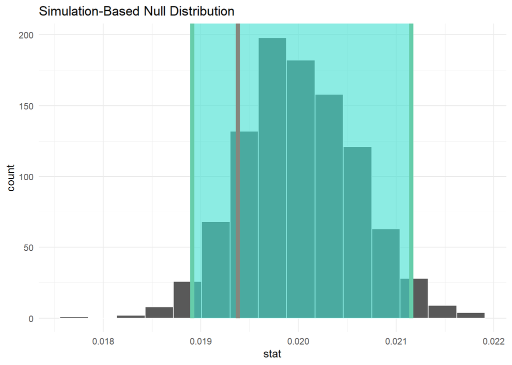

```r
visualise(bootDist) +
  shade_p_value(obs_stat = .01938, direction = NULL) +
  shade_confidence_interval(endpoints = get_ci(bootDist)) +
  theme_minimal()
```

Changed bootsrap to a simpler form. And used changed model. This model seems to show a normal distribution and I believe would support the original model.

### Problem 3

Explore your data further and find any variables that will work for a mixed-effects model and construct a new model. What does adding this new level to your model tell you?

```r
new_model <- lm(Total.Persons.Killed~ Train.Speed + Report.Year,
                    data = derailment)

summary(new_model)
```

```
##
## Call:
## lm(formula = Total.Persons.Killed ~ Train.Speed + Report.Year,
##     data = derailment)
##
## Residuals:
##    Min     1Q Median     3Q    Max
## -0.339 -0.021 -0.007  0.001 47.007
##
## Coefficients:
##               Estimate Std. Error t value Pr(>|t|)
## (Intercept) -7.311e-01  7.893e-02  -9.263   <2e-16 ***
## Train.Speed  2.263e-03  3.699e-05  61.168   <2e-16 ***
## Report.Year  3.636e-04  3.962e-05   9.176   <2e-16 ***
## ---
## Signif. codes:  0 '***' 0.001 '**' 0.01 '*' 0.05 '.' 0.1 ' ' 1
##
## Residual standard error: 0.2604 on 215843 degrees of freedom
##   (3 observations deleted due to missingness)
## Multiple R-squared:  0.01741,    Adjusted R-squared:  0.0174
## F-statistic:  1912 on 2 and 215843 DF,  p-value: < 2.2e-16
```

Adding Report Year does not seem to change this model. Originally I thought year would change train speed, but it still seems to hold weight here.